# Multi-level pca analysis

M.Davids

04 februari, 2021

# Introduction

“Work in progress”

An attempt for significance testing is implemented using a permutation manova on in the first x components. I’m not a statistician, so im not certain about reliability and interpretability.

Data used is from RED study (https://www.sciencedirect.com/science/article/abs/pii/S1262363619301855).

# Install and load required packages

```r
cran <- c("ggplot2",
          "ggpubr",
          NULL)
install.packages(cran[!cran %in% installed.packages()])

bioc. <- c("phyloseq",
           "mixOmics",
           NULL)
BiocManager::install(bioc.[!bioc. %in% installed.packages()])

library(phyloseq)
library(mixOmics)
library(ggplot2)
library(ggpubr)
```

# Read & wrangle data

```r
ps <- readRDS(url("https://github.com/AMCMC/MiCA-Tutorials/raw/master/Data_files/ps.2018_27_RED_study.2019-03-04.filtered.RDS"))
ps@sam_data$Treatment <- ps@sam_data$Randomization
```

Normalize the data by rarefaction without replacement.

```r
ps.mixomics <- rarefy_even_depth(ps, sample.size = 25000, rngseed = 21122, replace = F)
```

Only use subjects which have at least 2 time points.

```r
ps.mixomics <- prune_samples(ps.mixomics@sam_data$Subject_ID %in% names(which(table(ps.mixomics@sam_data$Subject_ID)!=1)), ps.mixomics)
table(ps.mixomics@sam_data$Treatment, ps.mixomics@sam_data$Time_Point)
```

```
##
##         0  1
##   DAPA 24 24
##   GLIC 17 17
```

The dataset contains 24 subjects that received DAPA, and 17 that recieved GLIC.

# Multilevel pca

Run the multilevel pca. We do CLR transformation of the data prior to multi-level pca Since we do CLR transformation we need to add a pseudocount. We are interested in within subject variance, so this is the multilvel specified.

```r
diverse.pca = pca(ps.mixomics@otu_table+1, ncomp = 10, logratio = 'CLR', multilevel = ps.mixomics@sam_data$Subject_ID)
```

```
## Splitting the variation for 1 level factor.
```

plot screeplot

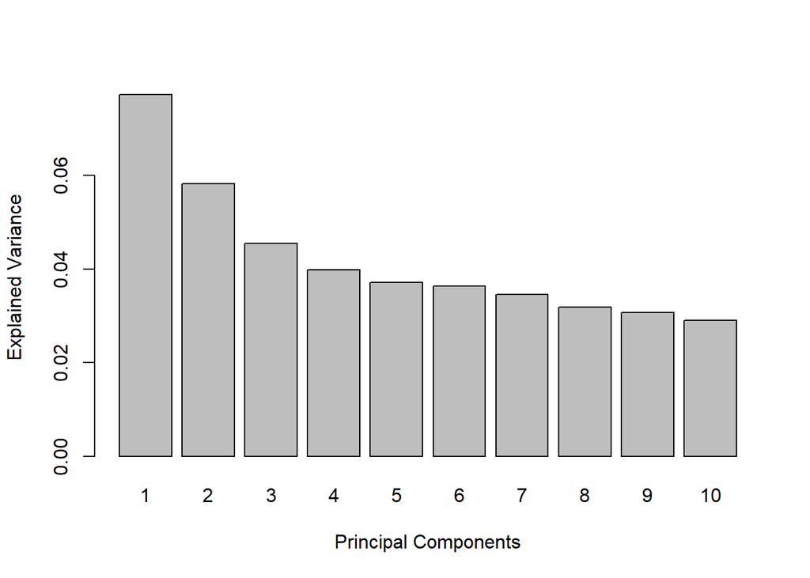

```r
plot(diverse.pca)
```

# Plot pca

Build a dataframe for plotting the pca results.

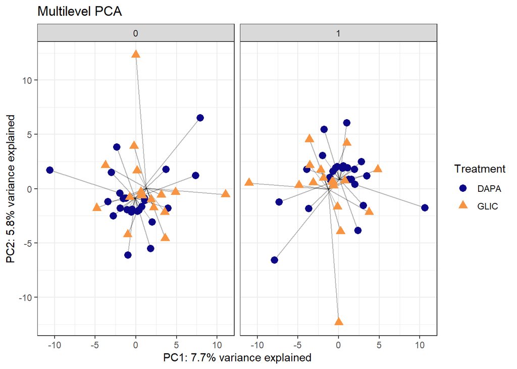

```r
time="Time_Point"
var="Treatment"
x="PC1" # first component
y="PC2" # second component

#build df
df <- data.frame(row.names = rownames(diverse.pca$x),
                 diverse.pca$x,
                 ps.mixomics@sam_data[rownames(diverse.pca$x),])

# include centroids
df$PTV_TP <- paste0(df[,var],df[,time])
centroids <- aggregate(diverse.pca$x~PTV_TP,data=df,mean)
df <- merge(df,centroids,by="PTV_TP",suffixes=c("",".centroid"))

# plot
p.multi.pca <- ggplot(df, aes_string(x=x, y=y, color=var, shape=var)) +
  geom_segment(aes_string(x=paste0(x,".centroid"), y=paste0(y,".centroid"), xend=x, yend=y), alpha=0.3, color="black") +
  scale_color_viridis_d(option = "C", end = 0.75) +
  theme_bw() +
  labs(x=paste0(x,": ",round(diverse.pca$explained_variance[x], 3)*100, "% variance explained"),
       y=paste0(y,": ",round(diverse.pca$explained_variance[y], 3)*100, "% variance explained"),
       title="Multilevel PCA") +
  facet_wrap(~Time_Point) +
  geom_point(size=3) +
  NULL; plot(p.multi.pca)
```

A possible shift in composition may be observed for DAPA (note centroid move)

# Plot loadings

We plot the loadings of the top 9 phyla on the first two components,

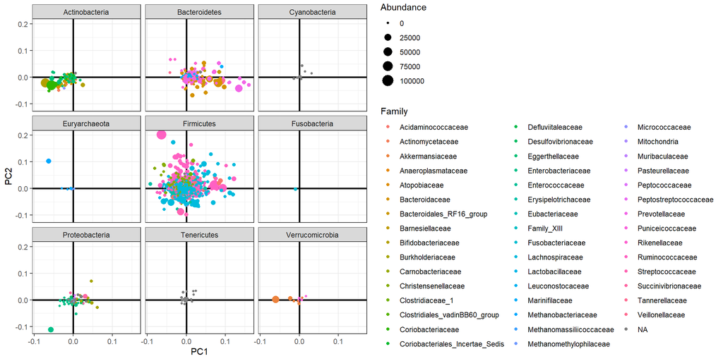

```r
PC1="PC1" # x
PC2="PC2" # y
Rank="Family" # color
size="Abundance" # size

# build df
df <- as.data.frame(diverse.pca$loadings$X[,c(PC1,PC2)]) # loadings
df <- cbind(df, ps@tax_table@.Data[rownames(df),]) # Include lineage
df$Abundance <- taxa_sums(ps.mixomics)[rownames(df)] # Abundance

# select top 9 phyla
phyl_abun <- aggregate(df$Abundance, by=list(df$Phylum), FUN=sum)
df <- df[df$Phylum %in% phyl_abun[order(phyl_abun[,2], decreasing = T)[1:9],1],]

#plot
p <- ggplot(df, aes_string(x=PC1, y=PC2, color=Rank,size=size)) +
  theme_bw() +
  geom_hline(yintercept = 0, color = "black", size = 1) +
  geom_vline(xintercept = 0, color = "black", size = 1) +
  geom_point() + facet_wrap(~Phylum); plot(p)
```

# Permutation significance testing

We test the significance by comparing the manova F-statistic to a set of permutation F-statistics (like adonis)

```r
df <- data.frame(row.names = rownames(diverse.pca$x),
                 diverse.pca$x,
                 ps.mixomics@sam_data[rownames(diverse.pca$x),])

true <- summary(manova(diverse.pca$x~Time_Point*Treatment, df))
true
```

```
##                      Df  Pillai approx F num Df den Df   Pr(>F)
## Time_Point            1 0.28826   2.7945     10     69 0.005808 **
## Treatment             1 0.00000   0.0000     10     69 1.000000
## Time_Point:Treatment  1 0.21461   1.8854     10     69 0.062060 .
## Residuals            78
## ---
## Signif. codes:  0 '***' 0.001 '**' 0.01 '*' 0.05 '.' 0.1 ' ' 1
```

Since the data is paired, I permute the time label within a subject and the treatment allocation among subjects.

*!Disclaimer: There are probably more elegant ways to code this but attempts with various packages failed and therefor I wrote this instead; Suggestions welcome* !I think its better to test significance using adonis using a similar permutation scheme

```r
permutations=999

permlist <- list()

#subject treatment allocation
Treatment <- df$Treatment[!duplicated(df$Subject_ID,)]
names(Treatment) <- df$Subject_ID[!duplicated(df$Subject_ID,)]

for (i in 1:(999)){ #not very elligant; maybe replace with perumation matrix
  vec.Treatment <- unname(sample(Treatment)) # shuffle group over subject
  names(vec.Treatment) <- names(Treatment)
  vec.Treatment <- vec.Treatment[df$Subject_ID]
  vec.time <- df$Time_Point
  for (subject in names(Treatment)){
    vec.time[df$Subject_ID %in% subject] <- sample(vec.time[df$Subject_ID %in% subject]) # shuffle time within subject
  }
  permlist[[i]] <- summary(manova(diverse.pca$x~vec.time*vec.Treatment))
}

df.pmmo <- data.frame(F1=unlist(lapply(permlist, function(x) x$stats[1,3])),F2=unlist(lapply(permlist, function(x) x$stats[2,3])),F3=unlist(lapply(permlist, function(x) x$stats[3,3])))
names(df.pmmo) <- c(rownames(permlist[[1]]$stats)[1],rownames(permlist[[1]]$stats)[2],rownames(permlist[[1]]$stats)[3])
df.pmmo.long <- reshape2::melt(df.pmmo)
```

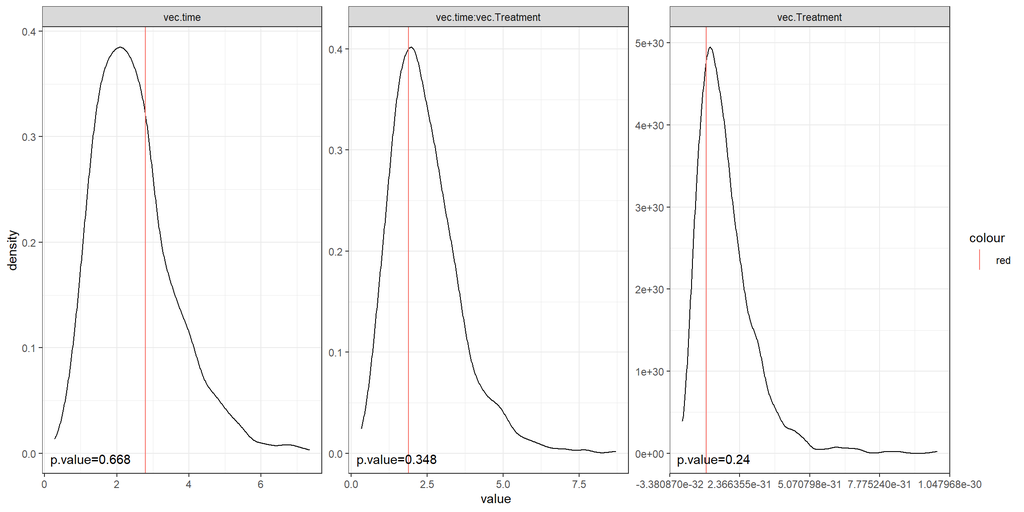

```r
p1=sum(true$stats[1,3]>=df.pmmo[,1])/(permutations+1)
p2=sum(true$stats[2,3]>=df.pmmo[,2])/(permutations+1)
p3=sum(true$stats[3,3]>=df.pmmo[,3])/(permutations+1)

df.dummy <- data.frame(variable=c(names(df.pmmo)[1],names(df.pmmo)[2],names(df.pmmo)[3]), Fstat=c(true$stats[1,3], true$stats[2,3],true$stats[3,3]), pval=paste0("p.value=",c(p1,p2,p3)))

p <- ggplot(df.pmmo.long, aes(x=value)) + geom_density() + facet_wrap(~variable, scales="free") +
  theme_bw() +
  geom_vline(data = df.dummy, aes(xintercept = Fstat, col="red")) +
  geom_text(data = df.dummy, aes(x = -Inf, y = -Inf, label = pval),  hjust   = -0.1, vjust   = -1) +
  NULL; plot(p)
```

This shows no significant results from the manova on the first 10 components.